# EDA Open Space

Will Kent

5 May 2019

#### Get Data

```r
# read cleaned data set
open_space_data <- read_csv("../Data Files/ABS/Open_Space_SA2.csv")
employed_data <- read_csv("../Data Files/ABS/Employed_SA2.csv")
sa2_data <- read_csv("../../Raw Data/Data Files/ABS/Mesh_Blocks/MB_2016_NSW.csv")

nsw_sa2 <- sa2_data %>%
  filter(STATE_NAME_2016 == "New South Wales") %>%
  distinct(SA2_MAINCODE_2016, SA2_NAME_2016)

# Get Open Space data for NSW only
nsw_os_data <- open_space_data %>%
  inner_join(nsw_sa2, by = c("SA2_CODE" = "SA2_MAINCODE_2016"))
```

#### Review data

```r
glimpse(nsw_os_data)
```

```
## Observations: 578
## Variables: 17
## $ SA2_CODE             <int> 101021007, 101021008, 101021009, 10102101...
## $ Commercial           <dbl> 0.0000, 0.0000, 0.4321, 0.0131, 0.0000, 0...
## $ Education            <dbl> 0.0237, 0.1155, 0.1556, 0.1014, 0.1173, 0...
## $ `Hospital/Medical`   <dbl> 0.0072, 0.0000, 0.0829, 0.0000, 0.0000, 0...
## $ Industrial           <dbl> 0.0000, 0.0000, 0.2300, 1.3813, 0.0000, 0...
## $ MIGRATORY            <int> 0, 0, 0, 0, 0, 0, 0, 0, 0, 0, 0, 0, 0, 0,...
## $ NOUSUALRESIDENCE     <int> 0, 0, 0, 0, 0, 0, 0, 0, 0, 0, 0, 0, 0, 0,...
## $ OFFSHORE             <int> 0, 0, 0, 0, 0, 0, 0, 0, 0, 0, 0, 0, 0, 0,...
## $ Other                <dbl> 947.8152, 1.6685, 0.0000, 0.0613, 843.979...
## $ Parkland             <dbl> 817.3813, 2.0158, 0.6249, 6.0458, 376.030...
## $ `Primary Production` <dbl> 1646.5519, 0.0000, 0.0000, 0.0000, 1636.8...
## $ Residential          <dbl> 6.5732, 3.1827, 3.2379, 5.4005, 43.1138, ...
## $ SHIPPING             <int> 0, 0, 0, 0, 0, 0, 0, 0, 0, 0, 0, 0, 0, 0,...
## $ Transport            <dbl> 0, 0, 0, 0, 0, 0, 0, 0, 0, 0, 0, 0, 0, 0,...
## $ Water                <dbl> 0.0000, 0.0000, 0.0000, 0.0000, 154.3354,...
## $ PERC_OPEN_SPACE      <dbl> 0.23911557, 0.28869316, 0.13118781, 0.464...
## $ SA2_NAME_2016        <chr> "Braidwood", "Karabar", "Queanbeyan", "Qu...
```

#### Explore data

Is the open space data normally distributed? Are there any glaring anomalies?

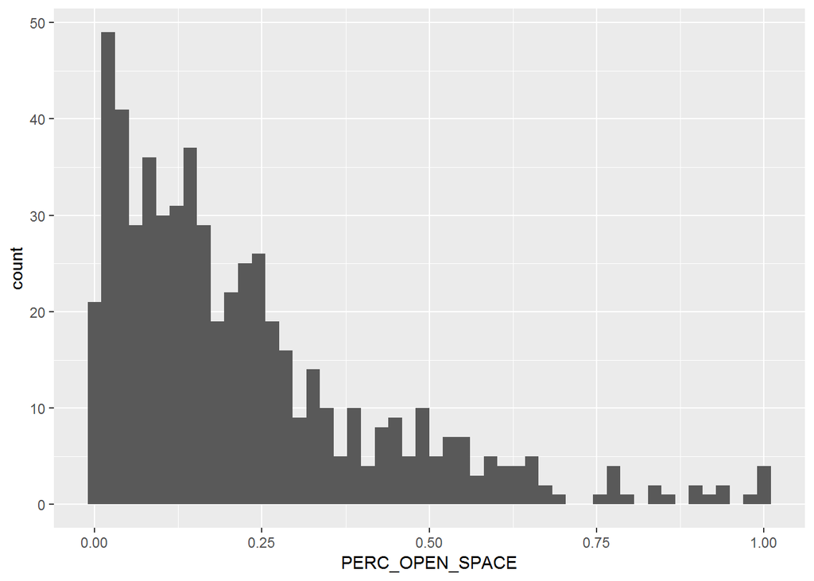

```r
# Have a look at the distribution of open space
nsw_os_data %>%
  ggplot() +
  geom_histogram(aes(x = PERC_OPEN_SPACE), bins = 50)
```

There are some SA2’s with no open space. Where are these communities?

```r
# There are some SA2's with no open space? and some that are 100%
a <- nsw_os_data %>%
  filter(PERC_OPEN_SPACE < 0.01) %>%
  select(SA2_CODE, SA2_NAME_2016, PERC_OPEN_SPACE)

a
```

```
## # A tibble: 21 x 3
##     SA2_CODE SA2_NAME_2016             PERC_OPEN_SPACE
##        <int> <chr>                               <dbl>
##  1 103011059 Bathurst - East                 0.00646
##  2 103021067 Parkes (NSW)                    0.00885
##  3 105011092 Bourke - Brewarrina             0.0000470
##  4 105011094 Coonamble                       0.00138
##  5 105011096 Walgett - Lightning Ridge       0.00667
##  6 105021097 Broken Hill                     0.00729
##  7 105031105 Narromine                       0.00767
##  8 105031106 Wellington                      0.000334
##  9 106021116 Maitland - North                0.00929
## 10 106041126 Muswellbrook                    0.00665
## # ... with 11 more rows
```

It seems rural areas have plenty of agricultural land but very limited public open space. There are a couple of Sydney suburbs in the list as well. Chullora in western Sydney is a hub for the NSW rail network and light industry, but evidently not open space. Another is Kingsford in Sydney’s Eastern suburbs which borders the University of New South Wales and is surrounded by private golf clubs. It has no open space but it isn’t far from Coogee Beach which is probably fair compensation.

Where are the places with high levels of open space?

```r
nsw_os_data %>%
  filter(PERC_OPEN_SPACE > 0.9) %>%
  select(SA2_CODE, SA2_NAME_2016, PERC_OPEN_SPACE)
```

```
## # A tibble: 8 x 3
##    SA2_CODE SA2_NAME_2016              PERC_OPEN_SPACE
##       <int> <chr>                                <dbl>
## 1 101041022 Deua - Wadbilliga                    0.949
## 2 103031075 Wollangambe - Wollemi                1.000
## 3 121021404 Berowra - Brooklyn - Cowan           0.929
## 4 123021439 Holsworthy Military Area             1
## 5 124011451 Blue Mountains - North               0.987
## 6 125011475 Rookwood Cemetery                    1
## 7 128021533 Heathcote - Waterfall                0.911
## 8 128021537 Royal National Park                  1
```

Unsurprisngly these are mainly National Parks.

The data didn’t look normally distributed but we’ll do this for fun anyway.

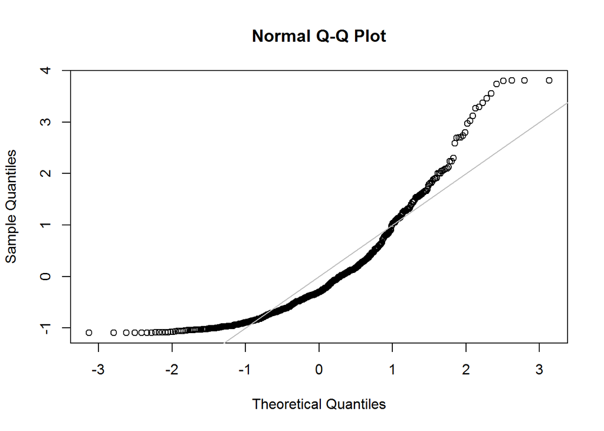

```r
os_std <- scale(nsw_os_data$PERC_OPEN_SPACE)
qqnorm(os_std)
abline(a = 0, b = 1, col = 'grey')
```

Yep definitely not normally distributed.

Rather than percent open space maybe we should check total open space (or parkland as the ABS calls it).

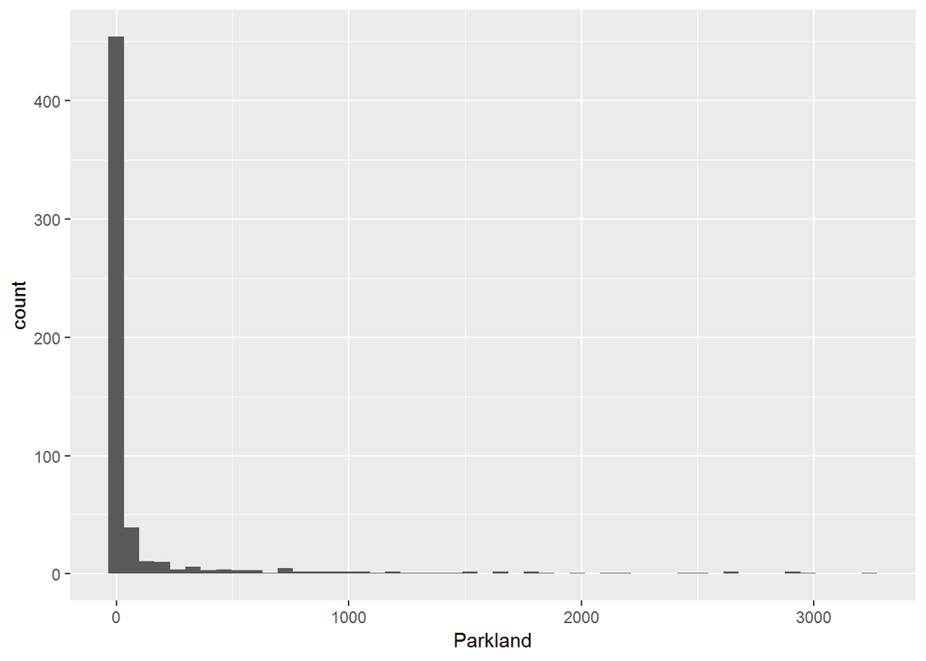

```r
nsw_os_data %>%
  ggplot() +
  geom_histogram(aes(x = Parkland), bins = 50)
```

Interesting - some SA2’s have a large about of open space (probably the National Parks) and then a whole bunch with not alot.

Before we go any further let’s check if there appears to be a relationship between open space and unemployment.

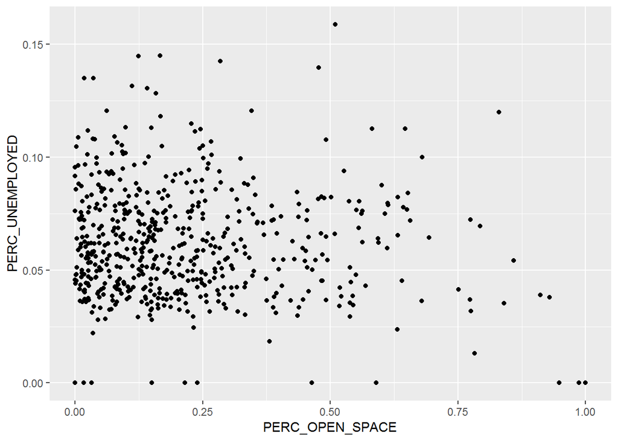

```r
# Let us do a check on Open Space and Unemployment
nsw_os_data %>%
  inner_join(employed_data, by = c("SA2_CODE")) %>%
  filter(PERC_UNEMPLOYED < 0.2) %>%
  ggplot() +
  geom_point(aes(x = PERC_OPEN_SPACE, y = PERC_UNEMPLOYED))
```

What a lot of dots. There doesn’t seem to be a pattern or relationship in there.

We can confirm there is no relationship with a correlation test.

```r
nsw_os_matrix <- nsw_os_data %>%
  inner_join(employed_data, by = c("SA2_CODE")) %>%
  filter(PERC_UNEMPLOYED < 0.2) %>%
  select(PERC_UNEMPLOYED,PERC_OPEN_SPACE) %>%
  as.matrix()

# Show values
rcorr(nsw_os_matrix, type = "pearson")
```

```
##                 PERC_UNEMPLOYED PERC_OPEN_SPACE
## PERC_UNEMPLOYED            1.00           -0.08
## PERC_OPEN_SPACE           -0.08            1.00
##
## n
##                 PERC_UNEMPLOYED PERC_OPEN_SPACE
## PERC_UNEMPLOYED             570             569
## PERC_OPEN_SPACE             569             569
##
## P
##                 PERC_UNEMPLOYED PERC_OPEN_SPACE
## PERC_UNEMPLOYED                 0.0687
## PERC_OPEN_SPACE 0.0687
```

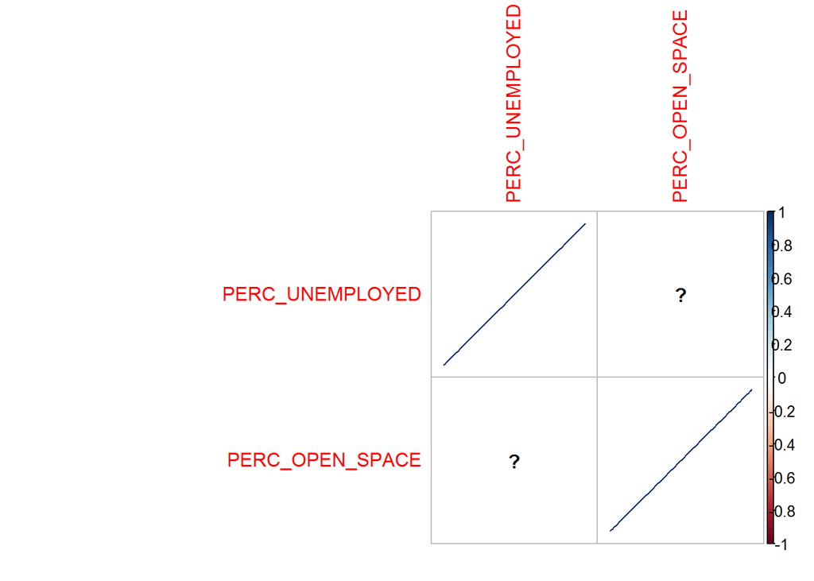

```r
# And a plot for good measure
corrplot(cor(nsw_os_matrix), method = "ellipse")
```

Even the computer doesn’t know. I reckon open space might go quickly when we get to the model.

And now we’ll do some map stuff. First with Greater Sydney.

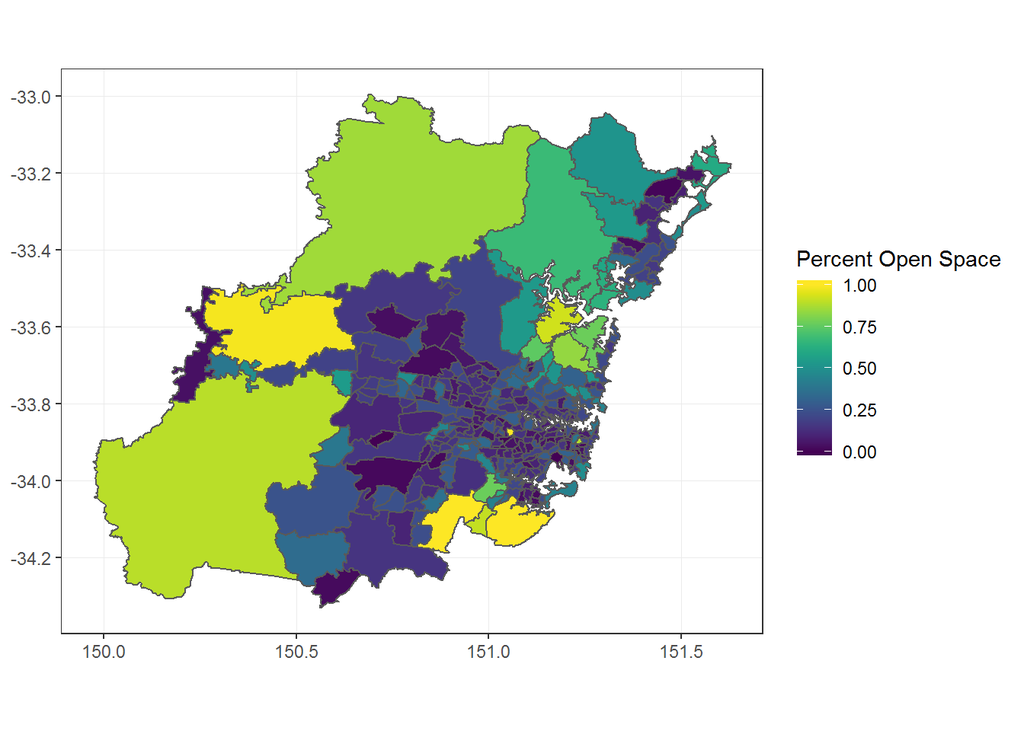

```r
# Lets have a look at this on a map
sa2_shape <- st_read("../../Raw Data/Data Files/ABS/SA2_Shapefile/SA2_2016_AUST.shp", quiet = TRUE)
combined_df <- merge(nsw_os_data, sa2_shape, by.x = "SA2_CODE", by.y = "SA2_MAIN16")

#Start with a view of Greater Sydney
combined_df %>%
  filter(GCC_NAME16 == "Greater Sydney") %>%
  ggplot() +
  geom_sf(aes(fill = PERC_OPEN_SPACE)) +
  scale_fill_viridis("Percent Open Space") +
  theme_bw()
```

Hardly surprising the outskirts of Sydney have a lot of open space, National Parks anyone? The inner city areas do not have as much open space.

And now we’ll try the rest of NSW.

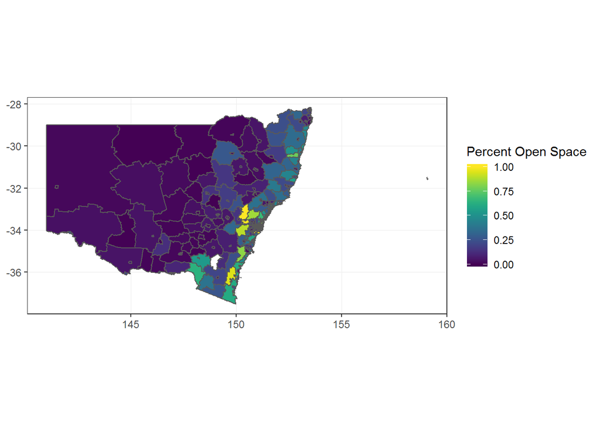

```r
# And the rest of NSW
combined_df %>%
  ggplot() +
  geom_sf(aes(fill = PERC_OPEN_SPACE)) +
  scale_fill_viridis("Percent Open Space") +
  theme_bw()
```

Western NSW has a lot of land for agriculture but not a lot of open space for the public. This validates what we saw earlier.

#### Conclusion

I reckon open space has no impact on unemployment.